# ENV 790.30 - Time Series Analysis for Energy Data | Spring 2023

Assignment 4 - Due date 02/17/23

Qiuying Liao

## Directions

You should open the .rmd file corresponding to this assignment on RStudio. The file is available on our class repository on Github. And to do so you will need to fork our repository and link it to your RStudio.

Once you have the file open on your local machine the first thing you will do is rename the file such that it includes your first and last name (e.g., “LuanaLima_TSA_A04_Sp23.Rmd”). Then change “Student Name” on line 4 with your name.

Then you will start working through the assignment by **creating code and output** that answer each question. Be sure to use this assignment document. Your report should contain the answer to each question and any plots/tables you obtained (when applicable).

When you have completed the assignment, **Knit** the text and code into a single PDF file. Submit this pdf using Sakai.

R packages needed for this assignment: “xlsx” or “readxl”, “ggplot2”, “forecast”,“tseries”, and “Kendall”. Install these packages, if you haven’t done yet. Do not forget to load them before running your script, since they are NOT default packages.\

```r
#Load/install required package here
library(readxl)
library(ggplot2)
library(forecast)
library(tseries)
library(Kendall)
library(dplyr)
library(lubridate)
```

## Questions

Consider the same data you used for A3 from the spreadsheet “Table_10.1_Renewable_Energy_Production_and_Consumption_by_Source.xlsx”. The data comes from the US Energy Information and Administration and corresponds to the December 2022 Monthly Energy Review. For this assignment you will work only with the column “Total Renewable Energy Production”.

```r
#Importing data set - using xlsx package

#Importing data set without change the original file using read.xlsx
energy_data <- read_excel(path="../Data/Table_10.1_Renewable_Energy_Production_and_Consumption_by_Source.xlsx",skip = 12, sheet="Monthly Data",col_names=FALSE)
#Now let's extract the column names from row 11
read_col_names <- read_excel(path="../Data/Table_10.1_Renewable_Energy_Production_and_Consumption_by_Source.xlsx",skip = 10,n_max = 1, sheet="Monthly Data",col_names=FALSE)
colnames(energy_data) <- read_col_names
head(energy_data)
```

| Month | Wood Energy Production | Biofuels Production | Total Biomass Energy Production | Total Renewable Energy Production | Hydroelectric Power Consumption | Geothermal Energy Consumption | Solar Energy Consumption | Wind Energy Consumption | Wood Energy Consumption | Waste Energy Consumption | Biofuels Consumption | Total Biomass Energy Consumption | Total Renewable Energy Consumption |
| --- | --- | --- | --- | --- | --- | --- | --- | --- | --- | --- | --- | --- | --- |
| 1973-01-01 | 129.630 | Not Available | 129.787 | 403.981 | 272.703 | 1.491 | Not Available | Not Available | 129.630 | 0.157 | Not Available | 129.787 | 403.981 |
| 1973-02-01 | 117.194 | Not Available | 117.338 | 360.900 | 242.199 | 1.363 | Not Available | Not Available | 117.194 | 0.144 | Not Available | 117.338 | 360.900 |
| 1973-03-01 | 129.763 | Not Available | 129.938 | 400.161 | 268.810 | 1.412 | Not Available | Not Available | 129.763 | 0.176 | Not Available | 129.938 | 400.161 |
| 1973-04-01 | 125.462 | Not Available | 125.636 | 380.470 | 253.185 | 1.649 | Not Available | Not Available | 125.462 | 0.174 | Not Available | 125.636 | 380.470 |
| 1973-05-01 | 129.624 | Not Available | 129.834 | 392.141 | 260.770 | 1.537 | Not Available | Not Available | 129.624 | 0.210 | Not Available | 129.834 | 392.141 |
| 1973-06-01 | 125.435 | Not Available | 125.611 | 377.232 | 249.859 | 1.763 | Not Available | Not Available | 125.435 | 0.176 | Not Available | 125.611 | 377.232 |

```r
#select column for data frame
energy_data_df <- energy_data[,c("Month","Total Renewable Energy Production")]

head(energy_data_df)
```

| Month | Total Renewable Energy Production |
| --- | --- |
| 1973-01-01 | 403.981 |
| 1973-02-01 | 360.900 |
| 1973-03-01 | 400.161 |
| 1973-04-01 | 380.470 |
| 1973-05-01 | 392.141 |
| 1973-06-01 | 377.232 |

## Stochastic Trend and Stationarity Tests

### Q1

Difference the “Total Renewable Energy Production” series using function diff(). Function diff() is from package base and take three main arguments: * *x* vector containing values to be differenced; * *lag* integer indicating with lag to use; * *differences* integer indicating how many times series should be differenced.

Try differencing at lag 1 only once, i.e., make `lag=1` and `differences=1`. Plot the differenced series Do the series still seem to have trend?

*No, the series doesn’t seem to have trend since most values are fluctuating around 0.*

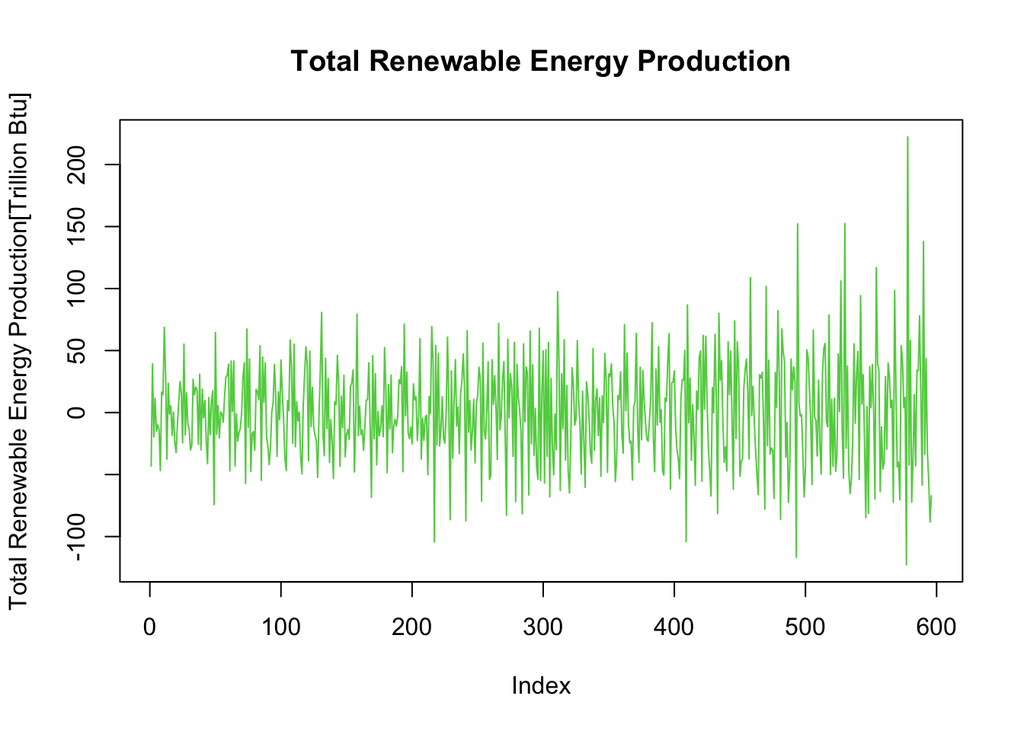

```r
difference_df <- diff(x = energy_data_df$`Total Renewable Energy Production`, lag = 1, differences = 1)

col_names <- colnames(energy_data_df)
cc <- palette()

for(i in 1){
plot(difference_df, type="l", col=cc[i+2], ylab = paste0(col_names[i+1], "[Trillion Btu]"), main=col_names[i+1])}
```

### Q2

Now let’s compare the differenced series with the detrended series you calculated on A3. In other words, for the “Total Renewable Energy Production” compare the differenced series from Q1 with the series you detrended in A3 using linear regression. (Hint: Just copy and paste part of your code for A3)

Copy and paste part of your code for A3 where you compute regression for Total Energy Production and the detrended Total Energy Production

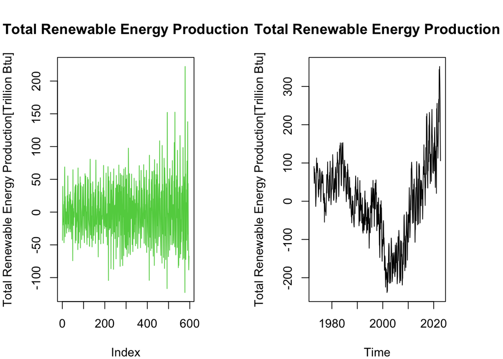

```r
#create time series
nobs <- nrow(energy_data_df)
t <- 1:nobs
ts_energy_data_df <- ts(energy_data_df[,2], start = c(1973,1), frequency =12)

#linear model
linear_trend2 <- lm(ts_energy_data_df[,1] ~ t)

#Renewable
beta0_2 <- linear_trend2$coefficients[1]
beta1_2 <- linear_trend2$coefficients[2]

detrend_energy_data_df2 <- ts_energy_data_df[,1]-(beta0_2+beta1_2*t)

for(i in 1){
  par(mfrow = c(1,2), mar = c(4,4,4,4))
  plot(difference_df, type="l", col=cc[i+2], ylab = paste0(col_names[i+1], "[Trillion Btu]"), main=col_names[i+1])
plot(detrend_energy_data_df2, type="l", col=cc[i], ylab=paste0(col_names[i+1], "[Trillion Btu]"), main=col_names[i+1])
}
```

### Q3

```r
#Data frame - remember to not include January 1973
energy_data_df_new <- energy_data_df[-1,]

#linear model
nobs_new <- nrow(energy_data_df_new)
t_new <- 1:nobs_new
ts_energy_data_df_new <- ts(energy_data_df_new[,2], start = c(1973,2), frequency =12)
linear_trend_new <- lm(ts_energy_data_df_new[,1] ~ t_new)

#Renewable:detrend
beta0_new <- linear_trend_new$coefficients[1]
beta1_new <- linear_trend_new$coefficients[2]
detrend_energy_data_df_new <- ts_energy_data_df_new[,1]-(beta0_new+beta1_new*t_new)

#data frame
diff_energy_data_df <- data.frame(energy_data_df_new$Month,energy_data_df_new$`Total Renewable Energy Production`, detrend_energy_data_df_new, difference_df)

colnames(diff_energy_data_df) <- c('Month','Renewable Energy Production', 'Detrend Energy Production', 'Differenced Energy Production')



#can also use cbind
```

### Q4

Using ggplot() create a line plot that shows the three series together. Make sure you add a legend to the plot.

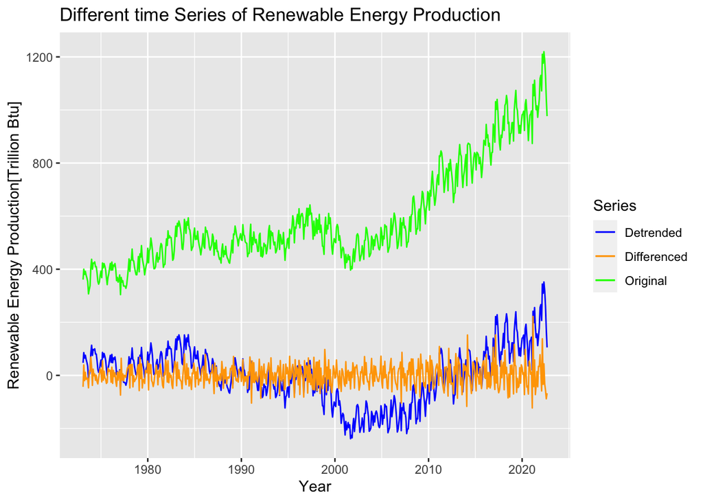

```r
colors <- c("Original" = "green", "Detrended" = "blue", "Differenced" = "orange")
ggplot(diff_energy_data_df, aes(x=Month))+
  geom_line(aes(y=diff_energy_data_df[,2], color = "Original"))+
  geom_line(aes(y=diff_energy_data_df[,3], color = "Detrended"))+
  geom_line(aes(y=diff_energy_data_df[,4], color = "Differenced"))+
  ylab(paste0(colnames(diff_energy_data_df)[(2)], sep="", "[Trillion Btu]"))+
  xlab("Year")+
  labs(title= "Different time Series of Renewable Energy Production")+
  scale_color_manual(name = "Series", values = colors)
```

### Q5

Plot the ACF for the three series and compare the plots. Add the argument `ylim=c(-0.5,1)` to the Acf() function to make sure all three y axis have the same limits. Which method do you think was more efficient in eliminating the trend? The linear regression or differencing?

*I think differencing was more efficient in eliminating the trend.**

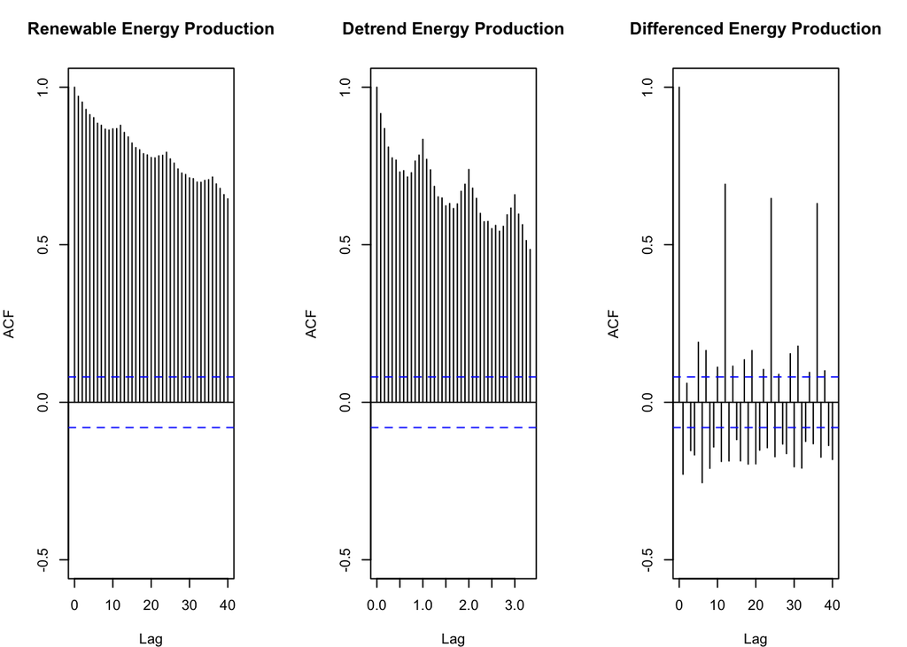

```r
#Compare ACF
  par(mfrow = c(1,3), mar = c(4,4,4,4))
  acf(diff_energy_data_df[,2], lag.max = 40, main = paste0(colnames(diff_energy_data_df)[(2)]), ylim=c(-0.5,1))
  acf(diff_energy_data_df[,3], lag.max = 40, main = paste0(colnames(diff_energy_data_df)[(3)]), ylim=c(-0.5,1))
  acf(diff_energy_data_df[,4], lag.max = 40, main = paste0(colnames(diff_energy_data_df)[(4)]), ylim=c(-0.5,1))
```

### Q6

Compute the Seasonal Mann-Kendall and ADF Test for the original “Total Renewable Energy Production” series. Ask R to print the results. Interpret the results for both test. Whats the conclusion from the Seasonal Mann Kendall test? What’s the conclusion for the ADF test? Do they match what you observed in Q2? Recall that having a unit root means the series has a stochastic trend. And when a series has stochastic trend we need to use a different procedure to remove the trend.

```r
#Seasonal Mann-Kendall
#Check for deterministic trend
SMKtest <- SeasonalMannKendall(ts_energy_data_df[,1])
print("Results for Seasonal Mann Kendall")
```

```
## [1] "Results for Seasonal Mann Kendall"
```

```r
print(summary(SMKtest))
```

```
## Score =  10577 , Var(Score) = 169001
## denominator =  14553
## tau = 0.727, 2-sided pvalue =< 2.22e-16
## NULL
```

*The p value for SMK test is less than 0.05, showing that it reject the null hypothesis and there is deterministic trend

```r
#Augmented Dickey Fuller (ADF)
#Used to detect stochastic trend

print("Results for ADF test")
```

```
## [1] "Results for ADF test"
```

```r
print(adf.test(ts_energy_data_df[,1], alternative = "stationary"))
```

```
##
##  Augmented Dickey-Fuller Test
##
## data:  ts_energy_data_df[, 1]
## Dickey-Fuller = -1.2055, Lag order = 8, p-value = 0.9056
## alternative hypothesis: stationary
```

### Q7

Aggregate the original “Total Renewable Energy Production” series by year. You can use the same procedure we used in class. Store series in a matrix where rows represent months and columns represent years. And then take the columns mean using function colMeans(). Recall the goal is the remove the seasonal variation from the series to check for trend.

```r
#group data in yearly steps
energy_data_matrix <- matrix(ts_energy_data_df[,1], byrow=FALSE, nrow=12)
energy_data_yearly <- colMeans(energy_data_matrix)
head(energy_data_yearly)
```

```
## [1] 367.5781 395.1543 390.5934 393.9292 350.7472 417.1201
```

### Q8

Apply the Mann Kendal, Spearman correlation rank test and ADF. Are the results from the test in agreement with the test results for the non-aggregated series, i.e., results for Q6?

```r
#Seasonal Mann-Kendall (use yearly data)
#Check for deterministic trend
print("Results of Mann Kendall on average yearly series")
```

```
## [1] "Results of Mann Kendall on average yearly series"
```

```r
print(summary(MannKendall(energy_data_yearly)))
```

```
## Score =  905 , Var(Score) = 14291.67
## denominator =  1225
## tau = 0.739, 2-sided pvalue =< 2.22e-16
## NULL
```

```r
#Spearman Correlation Test (use yearly data)
#Also check for deterministic trend, for non-seasonal data only

#my_date <- paste(energy_data_df[,1])

#print("Results from Spearman Correlation")
#sp_rho=cor(energy_data_yearly,year,method="spearman")
#print(sp_rho)

#with cor.test you can get test statistics
#sp_rho=cor.test(energy_data_yearly,my_year,method="spearman")
#print(sp_rho)
```

```r
#Augmented Dickey Fuller (ADF) (use yearly data)
#Used to detect stochastic trend

print("Results for ADF test")
```

```
## [1] "Results for ADF test"
```

```r
print(adf.test(energy_data_yearly, alternative = "stationary"))
```

```
##
##  Augmented Dickey-Fuller Test
##
## data:  energy_data_yearly
## Dickey-Fuller = -1.6251, Lag order = 3, p-value = 0.7247
## alternative hypothesis: stationary
```